# Stage 2b: the full eleven-country system

103 equations in one system_of_equations() — scaling, the degrees-of-freedom wall, and the Ireland and trade-weight decisions

## 1. The wall we hit first

The eleven-country system **cannot be estimated on the window stage 1 and stage 2a use**, and the reason is structural rather than a matter of patience.

koma’s sampler projects *every* equation on the **full** `k`-column `x_matrix` on *every* draw — `construct_pi_hat_0()` and `construct_theta_hat_j()` both compute `Matrix::solve(t(x) %*% x)` — and it draws the covariance from `riwish(T - k, .)`. Both need `k < T`. At eleven countries on the 2019Q4 window that is `k = 83` against `T = 78`, which fails twice over:

[output not shown]

Residual degrees of freedom `T - k` across the options:

| estimation end | T | 4 EA | 6 EA | 8 EA | 10 EA | 10 EA + US |
| --- | --- | --- | --- | --- | --- | --- |
| 2019Q4 (stage 1 / 2a) | 78 | 45 | 31 | 17 | **3** | **fails (−5)** |
| 2024Q4 (**stage 2b**) | 98 | 65 | 51 | 37 | 23 | 15 |
| 2026Q1 (panel end) | 103 | 70 | 56 | 42 | 28 | 20 |

Even ten EA countries on the old window leaves 3 df — invertible, but the reduced-form projection would be very nearly interpolating the data.

**What stage 2b changes to buy the room**, and what each costs:

- **Estimation window 2000Q1–2024Q4** (T = 98) instead of 2019Q4. This gives up the conditional-fill trick that neutralised COVID in stages 1 and 2a, so COVID is controlled with dummies instead of excluded.
- **`<iso2>_government` leaves the model.** It appears only in the domestic-demand identity, so dropping it there removes it entirely and returns 11 exogenous columns. The identity becomes `dd == a*consumption + b*investment` with the shares **renormalised to sum to 1** — left raw they sum to ~0.8 and would systematically under-predict domestic-demand growth. The cost is real and worth stating: government is ~19.7% of GDP, the omitted term `share_G × g(G)` has median sd 0.222pp against `g(dd)` median sd 2.005pp, so **the identity now explains about 89% of domestic-demand growth variation rather than ~100%**, and the model has no fiscal channel at all.
- **Four COVID dummies**, `2020Q1/Q2/Q3` and `2021Q2` — the only quarters whose cross-country mean absolute GDP growth exceeds 3× the non-COVID baseline of 0.81pp (they run 3.16, 12.19, 10.68, 2.48). They enter the five real-side equations only; `long_rate` and the policy rules show no mechanical COVID break.

Net: **k = 76, T = 98, df = 22.**

An alternative bought the same 11 columns with no accounting damage — drop the `imports` own-lag, insignificant in 7 of 11 stage-1 fits — but it leaves government exogenous and so breaks the three-variable exogenous spec. It is recorded here as the option not taken.

## 2. The system

The eleven-country system.

| quantity | value |
| --- | --- |
| stochastic equations | 68 |
| identities | 35 |
| endogenous variables | 103 |
| exogenous variables | 7 |
| predetermined (lags) | 68 |
| k = 1 + lags + exogenous | 76 |
| T (2000Q3–2024Q4) | 98 |
| residual df | 22 |

Exogenous (7): `covid_2020q1`, `covid_2020q2`, `covid_2020q3`, `covid_2021q2`, `eur_usd`, `oil_price`, `row_gdp`.

Per EA country: `consumption`, `investment` (with `<cc>_long_rate`), `exports` (on `<cc>_foreign_demand`), `imports`, `prices`, `long_rate` (on the shared `ea_policy_rate`), plus `gdp`, `domestic_demand` and `foreign_demand` identities. The US adds `us_policy_rate ~ us_prices + us_gdp + us_policy_rate.L(1)` and loads its own `long_rate` on that instead. There is exactly **one** `ea_policy_rate` equation however many countries the system contains. Per the three-variable exogenous spec the US `prices` equation uses `eur_usd`, not the `us_exchange_rate` stage 1 and 2a gave it — which breaks continuity with the US block in both earlier stages.

Nothing here is hand-written: `build_system(countries, blocks, weights)` in `R/equations.R` assembles blocks (`country_block()`, `monetary_block()`, `ea_aggregate_block()`), and stage 3 extends it by adding a block rather than editing the country loop.

Pre-flight. The k < T row is new in stage 2b and exists because of §1.

| check | ok | detail |
| --- | --- | --- |
| identity RHS variables all resolve | TRUE | - |
| no variable defined twice | TRUE | - |
| every variable has a panel series | TRUE | 110 variables present |
| no internal NAs in required series | TRUE | - |
| identities declared last | TRUE | 68 stochastic then 35 identities |
| system identified | TRUE | 10/10 seeds pass order + rank |
| k < T (x’x invertible, Wishart df > 0) | TRUE | k = 76, T = 98, df = 22 |

## 3. Scaling

All four steps ran under the identical stage-2b configuration and 8 workers, so only the country count varies. The stage-2a fit is **not** a point on this curve — different window, different `k`.

Benchmark. Acceptance rates are at the default tau = 1.1, before tuning.

| step | countries | stochastic | identities | equations | k | df | seconds | peak_mem_mb | fit_mb | min_acceptance | max_acceptance | n_flagged |
| --- | --- | --- | --- | --- | --- | --- | --- | --- | --- | --- | --- | --- |
| DE+FR | 2 | 13 | 8 | 21 | 21 | 77 | 19.2 | 60.2 | 15.6 | 0.2725 | 0.6015 | 1 |
| DE+FR+IT+ES | 4 | 25 | 14 | 39 | 33 | 65 | 41.5 | 105.2 | 32.8 | 0.2765 | 0.6145 | 4 |
| 10 EA | 10 | 61 | 32 | 93 | 69 | 29 | 168.7 | 170.2 | 102.2 | 0.2740 | 0.6205 | 12 |
| 10 EA + US | 11 | 68 | 35 | 103 | 76 | 22 | 229.7 | 255.8 | 119.3 | 0.2910 | 0.6160 | 14 |

Fitting `log(seconds) ~ log(stochastic equations)` on the **first three** steps gave an exponent of **1.416** (R² 0.9940) — clearly superlinear — and projected the full system at **189 s**. It actually took **229.7 s**, an error of **+21.7%**. Across all four steps the exponent is **1.489** (R² 0.9919).

The exponent lands almost exactly on koma’s own documented `n^1.4`. It is superlinear because `k` grows with the system and `solve(t(x) %*% x)` is recomputed on every draw of every equation — cost scales with the equation count *and* with the per-equation work.

### The BLAS trap, which cost more than the scaling did

The first benchmark attempt was ~30× slower than these numbers and had to be killed. This R links a **pthread OpenBLAS** (`libopenblasp-r0.3.34.so`), and each process it runs in claims every core for its own thread pool. With `future::multicore` forking 8 workers, that is 8 × 16 threads on 16 cores:

- **load average 116** on a 16-core machine, each worker burning ~180% CPU;
- the 25-equation step **did not finish in twenty minutes**, against **41.5 s** once fixed.

The fix is to pin BLAS to one thread per process *before R starts*, so the parallelism is purely across equations:

```bash
OMP_NUM_THREADS=1 OPENBLAS_NUM_THREADS=1 Rscript ...
```

It must be the environment rather than `Sys.setenv()` in-session, because OpenBLAS sizes its pool at library initialisation. Pinning costs nothing here — koma’s matrices are at most 76 × 76, far too small for threaded BLAS to repay its own synchronisation. `warn_if_blas_threaded()` now warns when `workers > 1` and the variables are unset.

## 4. Diagnostics

### Acceptance rates

At the default `tau = 1.1`, **14 of 68** equations sat outside the 20–60% band, all marginally over the ceiling. One round at `tau = 2.2` cleared every one, leaving the band at **[0.291, 0.599]**.

The tuned equations, before and after.

| equation | acceptance_rate_before | acceptance_rate_after |
| --- | --- | --- |
| be_consumption | 0.6140 | 0.4135 |
| be_imports | 0.6005 | 0.4055 |
| de_consumption | 0.6130 | 0.4210 |
| de_imports | 0.6125 | 0.4145 |
| es_consumption | 0.6160 | 0.4220 |
| fr_exports | 0.6125 | 0.4215 |
| fr_imports | 0.6135 | 0.4315 |
| gr_consumption | 0.6080 | 0.4265 |
| gr_exports | 0.6130 | 0.4325 |
| gr_imports | 0.6080 | 0.4085 |
| nl_exports | 0.6045 | 0.4105 |
| nl_imports | 0.6125 | 0.4205 |
| pt_imports | 0.6110 | 0.4275 |
| us_consumption | 0.6160 | 0.4320 |

### Convergence

`check_running_mean_stability()` examined **538** coefficients across all 68 equations and flagged **0**. No chain is still drifting in its final third.

### Coefficient plausibility

Sign checks across all eleven countries.

| check | FALSE | TRUE |
| --- | --- | --- |
| import_elasticity_positive | 0 | 11 |
| long_rate_loads_on_policy_rate | 2 | 9 |
| mpc_in_0_1 | 0 | 11 |

Violations, reported not corrected.

| country | check | equation | term | estimate |
| --- | --- | --- | --- | --- |
| gr | long_rate_loads_on_policy_rate | gr_long_rate | ea_policy_rate | -0.0486 |
| pt | long_rate_loads_on_policy_rate | pt_long_rate | ea_policy_rate | -0.0130 |

This is a **marked improvement on stage 1**, which failed six of these checks. `mpc_in_0_1` and `import_elasticity_positive` now pass 11/11 — including Spain, whose stage-1 MPC was an implausible 1.20, and Ireland, whose was effectively zero. Only `long_rate_loads_on_policy_rate` still fails, in Greece (−0.049) and Portugal (−0.013), both near-zero rather than meaningfully wrong-signed; stage 1 failed it in four countries.

### The linkage

Export elasticity on trade-weighted foreign demand.

| equation | estimate | ci_low | ci_high | excludes_zero |
| --- | --- | --- | --- | --- |
| at_exports | 3.627 | 2.251 | 5.254 | TRUE |
| pt_exports | 3.067 | 0.801 | 5.384 | TRUE |
| it_exports | 2.920 | 1.240 | 4.382 | TRUE |
| es_exports | 2.775 | 1.076 | 4.368 | TRUE |
| nl_exports | 2.643 | 0.978 | 4.321 | TRUE |
| be_exports | 2.043 | -0.004 | 3.871 | FALSE |
| fr_exports | 1.967 | 0.422 | 3.487 | TRUE |
| de_exports | 1.840 | -0.211 | 3.899 | FALSE |
| gr_exports | 1.379 | -2.905 | 5.750 | FALSE |
| ie_exports | 0.797 | -4.430 | 6.134 | FALSE |
| us_exports | 0.023 | -0.857 | 0.833 | FALSE |

The US is the exception at 0.02 — see §5.

### The monetary block

The two policy rules.

| equation | term | estimate | ci_low | ci_high |
| --- | --- | --- | --- | --- |
| us_policy_rate | constant | -0.101 | -0.377 | 0.182 |
| us_policy_rate | us_policy_rate.L(1) | 0.955 | 0.868 | 1.042 |
| us_policy_rate | us_prices | 0.206 | -0.073 | 0.477 |
| us_policy_rate | us_gdp | 0.080 | -0.049 | 0.226 |
| ea_policy_rate | constant | -0.100 | -0.276 | 0.084 |
| ea_policy_rate | ea_policy_rate.L(1) | 0.980 | 0.927 | 1.036 |
| ea_policy_rate | ea_gdp | 0.006 | -0.047 | 0.065 |
| ea_policy_rate | ea_prices | 0.253 | 0.079 | 0.435 |

The euro-area Taylor rule loads **+0.253 on `ea_prices`** with an interval excluding zero, but only **+0.006 on `ea_gdp`** — it responds to inflation and essentially not to output. Both rules are close to a unit root in their own lag (0.98, 0.96), as policy rates are.

The rate -> investment channel that gives policy a route to GDP.

| equation | estimate | ci_low | ci_high |
| --- | --- | --- | --- |
| at_investment | -0.183 | -0.601 | 0.256 |
| be_investment | -0.160 | -0.850 | 0.399 |
| de_investment | -0.066 | -0.342 | 0.268 |
| gr_investment | 0.019 | -0.638 | 0.630 |
| es_investment | -0.017 | -0.414 | 0.386 |
| fr_investment | 0.007 | -0.201 | 0.183 |
| ie_investment | -2.535 | -7.107 | 2.231 |
| it_investment | -0.202 | -0.662 | 0.302 |
| nl_investment | -0.256 | -2.428 | 2.073 |
| pt_investment | -0.466 | -0.928 | -0.036 |
| us_investment | -0.311 | -0.951 | 0.368 |

Nine of eleven are correctly signed (negative), but only Portugal’s interval excludes zero. The channel exists structurally — which is what stage 2a established it must, for a policy shock to reach GDP at all — but it is not sharply estimated.

## 5. Ireland

The brief proposed swapping Irish GDP for modified domestic demand. **On this panel that would make things four times worse**, because the multinational distortion lives in `ie_investment`, which is *inside* domestic demand:

| series | sd | max abs | quarters >10pp |
| --- | --- | --- | --- |
| `ie_gdp` | 4.00 | 22.1 | 4 |
| `ie_domestic_demand` (proposed) | **17.39** | **80.0** | **21** |
| `ie_investment` (the culprit) | 38.01 | 148.5 | — |
| `ie_consumption` (**used**) | 2.54 | 13.3 | 2 |
| `ie_consumption + ie_government` | 1.76 | 9.5 | 0 |

The CSO’s real Modified Domestic Demand strips exactly the IP and aircraft-leasing components; we have no such series. `ie_consumption` is the best-behaved Irish demand series that is **already endogenous**, which is what makes the A/B clean: swapping it in changes no equation count, no `k` and no degrees of freedom, so the two fits are directly comparable. `C+G` would be marginally better still but needs its own identity plus `ie_government` back as an exogenous, costing a column and breaking that comparability.

Export elasticity with partners loading on ie_gdp vs ie_consumption. Both fits at tau = 1.1.

| equation | ie_weight | estimate_gdp | estimate_proxy | delta |
| --- | --- | --- | --- | --- |
| us_exports | 0.247 | 0.023 | 0.982 | 0.959 |
| nl_exports | 0.039 | 2.523 | 1.994 | -0.529 |
| be_exports | 0.038 | 2.043 | 1.739 | -0.304 |
| fr_exports | 0.028 | 1.925 | 1.949 | 0.024 |
| pt_exports | 0.027 | 3.067 | 3.002 | -0.066 |
| de_exports | 0.025 | 1.840 | 1.981 | 0.141 |
| it_exports | 0.024 | 2.920 | 2.868 | -0.052 |
| gr_exports | 0.023 | 1.013 | 1.048 | 0.036 |
| es_exports | 0.022 | 2.775 | 2.770 | -0.005 |
| at_exports | 0.016 | 3.627 | 3.679 | 0.051 |
| ie_exports | 0.000 | 0.797 | 0.797 | 0.000 |

**The contamination is almost entirely one cell.** The median absolute change across the ten non-US countries is **0.051**; for `us_exports` it is **+0.959** — twenty times larger.

That is exactly where theory said to look: Ireland’s weight in the US row is **0.247**, an order of magnitude above its 0.016–0.039 in every EA partner, and it is precisely the `W_trade["us","ie"]` cell CLAUDE.md already flags as unreliable — inflated by the same multinational redomiciliation that distorts Irish GDP, and reached through the reciprocal approximation used because the ECB publishes no US-reporter series.

The effect is economically decisive for that equation: the US export elasticity moves from **0.02** (implausibly flat) to **0.98**. Acceptance rates are identical across the two variants (min 0.291, max 0.616, 14 flagged each), confirming the comparison isolates the swapped variable.

**Recommendation: use the proxy.** Not because Ireland pollutes everyone — it does not, at a median delta of 0.05 — but because it badly distorts the one partner whose weight on it is already known to be wrong.

## 6. Trade weights and Greece

### Threshold: fold below 1% into `row`

Applied. It drops 18 of 110 bilateral cells (16.4%) carrying **1.6%** of total bilateral mass; 92 cells survive, and the folded weight goes into `row_gdp` so every row still sums to 1.

**One correction to the brief’s rationale: this does not estimate faster.** koma samples only *stochastic* equation columns, and `foreign_demand` is an identity — identity columns are never sampled, so their density has essentially no effect on Gibbs cost. The real arguments are identification (every zeroed cell is an extra exclusion restriction, and the rank condition is what binds in a 103-equation system), interpretability, and a sparser, better-conditioned `Gamma` for the forecast solve.

### Greece: not ragged, no truncation needed

The premise does not hold for this vintage. Checked in both the aligned panel and the raw `global_panel` target: **every EA country, Greece included, starts 2000Q1 and runs to 2026Q1 with zero NAs.** The only late starter anywhere is `es_core_prices` (2001Q1), a concept this system does not use.

The real Greek issue is already handled elsewhere: `gr_long_rate` has one *internal* gap at 2015Q3, when capital controls shut the bond market, and `fill_internal_gaps()` interpolates it with a warning.

On the general question — koma handles a ragged panel at the **edges** only. `fill_ragged_edge()` conditionally fills leading and trailing gaps during `estimate()`; an internal hole fails with an opaque error from inside `level()`. Note that `fill_ragged_edge()`’s `readline()` is **not** `interactive()`-guarded, so under `Rscript` or `targets` a ragged edge inside the estimation window is silently *not* filled — which is why the pre-flight asserts the window is gap-free rather than trusting the fill.

## 7. Verdict

The eleven-country system estimates, converges and is identified. 68 stochastic equations and 35 identities in one `system_of_equations()`, 230s on 8 workers, all acceptance rates in band after one tuning round, zero unstable chains, and export elasticities that are positive everywhere and significant in most places — the linkage now does real work, which it did not in the two-country pilot.

Three things to carry forward:

- **The df budget is now the binding constraint on the model.** At k = 76 against T = 98 there are 22 residual degrees of freedom, and *every* additional equation or exogenous costs one. Stage 3 cannot add much to this system without either a longer sample or something coming out.
- **Government is gone, and with it any fiscal channel.** The domestic-demand identity explains ~89% of its own growth variation rather than ~100%. If fiscal policy matters for stage 3, this is the thing to revisit first.
- **The `W_trade["us", ]` row remains the weakest input.** The Ireland result is really a symptom: the US row is a reciprocal approximation, and the one cell where it is most distorted is the one that moved the most.

## Eight-quarter forecast

8 quarters from **2025Q1** to **2026Q4**, 1000 posterior draws. Actuals exist for the first 5 quarters; the rest is genuinely ahead of the data.

Every fan below is the **filtered** predictive interval: koma constrains no draw to be stationary, so a draw whose quarterly growth exceeds 100% in absolute value is dropped before the quantiles are taken, exactly as `score_forecast()` does when it scores a backtest. The solid band is the 25th-75th percentile of what survives, the faint band the 10th-90th, the dark line their median, and the grey line the realised path where one exists. Across the variables shown, **3.4%** of draws are discarded as explosive at horizon 1, rising to **29.9%** at horizon 8 (worst: `at_gdp` at 66.4%). A variable whose discarded share climbs steeply is one whose fan **understates** the model’s true uncertainty, so read the tail of a wide fan as an ordering rather than a number.

**The panels are clipped, and that is worth saying plainly.** Eight quarters out, the 10-90 interval on *quarterly* growth spans tens of percentage points in every stage of this project – an honest number, and one that makes the median invisible if the axis is scaled to contain it. Each panel is therefore scaled to its inner band, and the outer band runs to the panel edge rather than being drawn in full. Nothing is concealed: the table at the end of this section reports the untruncated bounds.

Every level path is anchored on an **observed** value (largest anchor discrepancy 0.00%, on `at_imports`), so the level and rate charts are both directly comparable to the actuals.

### GDP

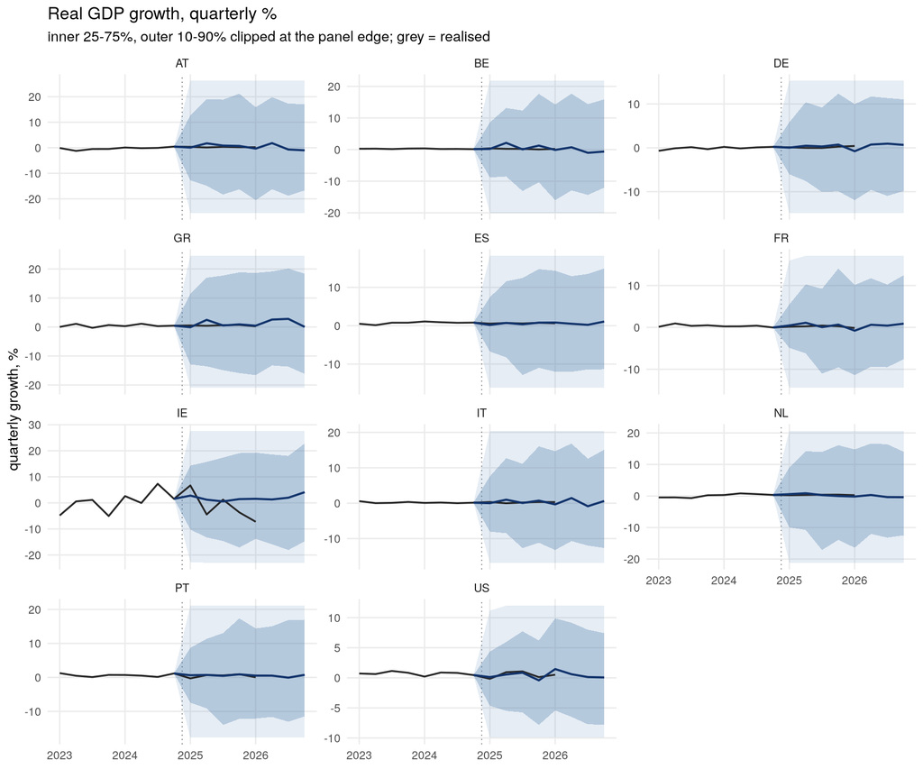

Median GDP growth forecast by quarter, percent.

| quarter | AT | BE | DE | GR | ES | FR | IE | IT | NL | PT | US |
| --- | --- | --- | --- | --- | --- | --- | --- | --- | --- | --- | --- |
| 2025Q1 | 0.08 | 0.21 | 0.04 | -0.08 | 0.19 | 0.46 | 2.78 | 0.02 | 0.58 | 0.64 | 0.12 |
| 2025Q2 | 1.75 | 2.13 | 0.48 | 2.46 | 0.73 | 1.11 | 1.22 | 1.00 | 0.87 | 0.73 | 0.56 |
| 2025Q3 | 0.85 | 0.07 | 0.31 | 0.54 | 0.36 | 0.06 | 0.56 | 0.06 | 0.29 | 0.46 | 0.85 |
| 2025Q4 | 0.71 | 1.27 | 0.74 | 0.91 | 0.80 | 0.66 | 1.45 | 0.73 | -0.01 | 0.91 | -0.42 |
| 2026Q1 | -0.32 | -0.11 | -0.77 | 0.45 | 0.83 | -0.78 | 1.56 | -0.33 | -0.17 | 0.53 | 1.46 |
| 2026Q2 | 1.82 | 0.73 | 0.75 | 2.57 | 0.51 | 0.63 | 1.31 | 1.45 | 0.32 | 0.52 | 0.60 |
| 2026Q3 | -0.69 | -1.01 | 0.95 | 2.80 | 0.23 | 0.42 | 1.98 | -0.86 | -0.35 | -0.07 | 0.13 |
| 2026Q4 | -1.00 | -0.62 | 0.67 | 0.04 | 1.09 | 0.89 | 4.11 | 0.62 | -0.39 | 0.75 | 0.07 |

### Prices

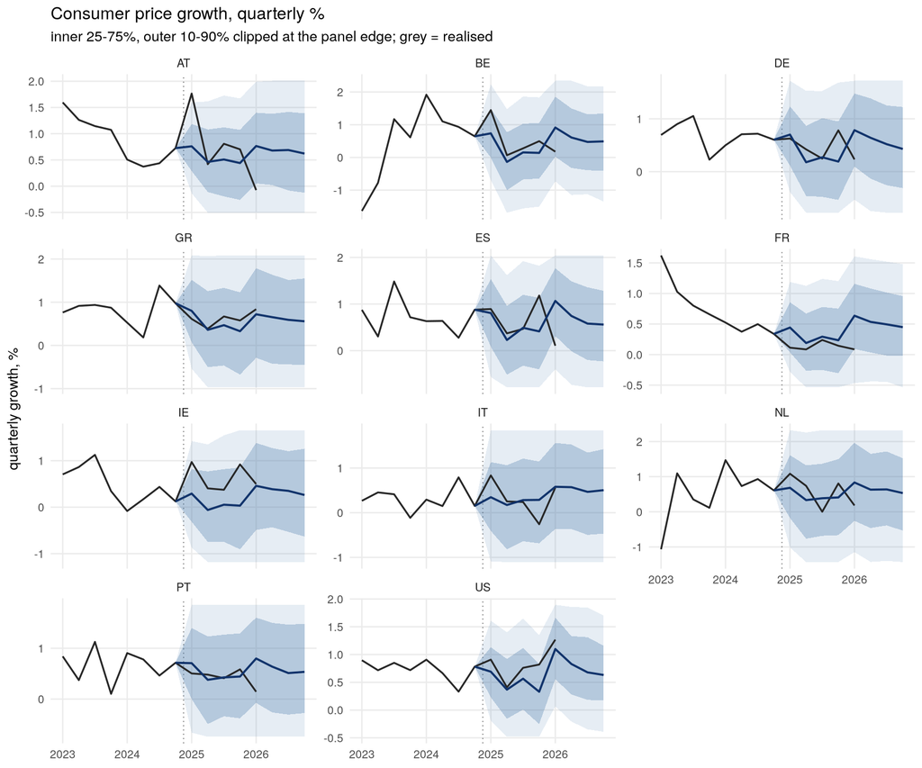

Median price growth forecast by quarter, percent.

| quarter | AT | BE | DE | GR | ES | FR | IE | IT | NL | PT | US |
| --- | --- | --- | --- | --- | --- | --- | --- | --- | --- | --- | --- |
| 2025Q1 | 0.76 | 0.74 | 0.70 | 0.80 | 0.81 | 0.44 | 0.29 | 0.35 | 0.68 | 0.71 | 0.69 |
| 2025Q2 | 0.46 | -0.14 | 0.18 | 0.36 | 0.23 | 0.19 | -0.06 | 0.17 | 0.33 | 0.38 | 0.37 |
| 2025Q3 | 0.51 | 0.15 | 0.27 | 0.47 | 0.49 | 0.29 | 0.05 | 0.28 | 0.39 | 0.43 | 0.56 |
| 2025Q4 | 0.44 | 0.14 | 0.19 | 0.33 | 0.41 | 0.23 | 0.03 | 0.29 | 0.41 | 0.44 | 0.33 |
| 2026Q1 | 0.77 | 0.91 | 0.78 | 0.72 | 1.07 | 0.64 | 0.46 | 0.58 | 0.83 | 0.80 | 1.10 |
| 2026Q2 | 0.68 | 0.61 | 0.64 | 0.65 | 0.74 | 0.54 | 0.39 | 0.57 | 0.63 | 0.64 | 0.83 |
| 2026Q3 | 0.69 | 0.47 | 0.52 | 0.59 | 0.58 | 0.49 | 0.35 | 0.47 | 0.64 | 0.51 | 0.68 |
| 2026Q4 | 0.62 | 0.49 | 0.43 | 0.56 | 0.56 | 0.45 | 0.26 | 0.50 | 0.53 | 0.54 | 0.63 |

### Policy rates

A `method = "none"` series passes through koma untouched, so for a policy rate the forecast **is** the level – there is no rate-versus-level distinction to make, and no anchoring question either.

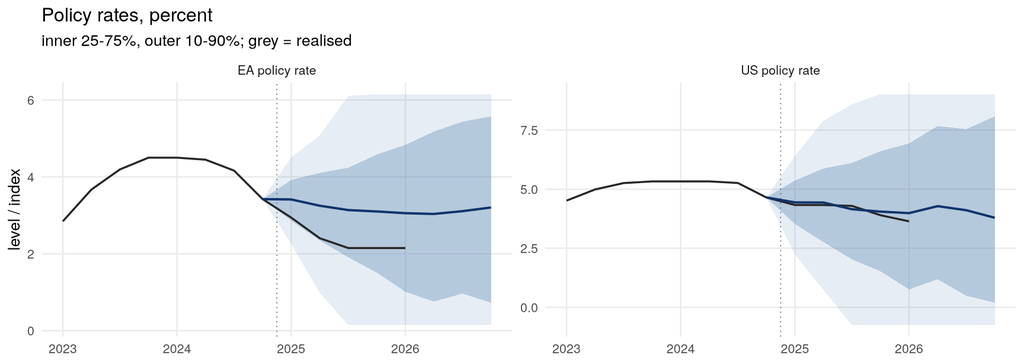

Median policy-rate path, percent.

| quarter | ea_policy_rate | us_policy_rate |
| --- | --- | --- |
| 2025Q1 | 3.41 | 4.44 |
| 2025Q2 | 3.25 | 4.44 |
| 2025Q3 | 3.14 | 4.15 |
| 2025Q4 | 3.10 | 4.05 |
| 2026Q1 | 3.06 | 3.99 |
| 2026Q2 | 3.04 | 4.28 |
| 2026Q3 | 3.11 | 4.11 |
| 2026Q4 | 3.20 | 3.79 |

### What was discarded, and what the exogenous path assumes

Share of posterior draws discarded as explosive, by variable.

| variable | explosive share, h1 | h8 | max |
| --- | --- | --- | --- |
| at_gdp | 0.123 | 0.664 | 0.664 |
| gr_gdp | 0.133 | 0.621 | 0.621 |
| nl_gdp | 0.062 | 0.621 | 0.621 |
| it_gdp | 0.064 | 0.609 | 0.609 |
| es_gdp | 0.063 | 0.608 | 0.608 |
| pt_gdp | 0.084 | 0.608 | 0.608 |
| be_gdp | 0.059 | 0.606 | 0.606 |
| fr_gdp | 0.047 | 0.580 | 0.580 |
| ie_gdp | 0.047 | 0.574 | 0.574 |
| de_gdp | 0.045 | 0.567 | 0.567 |
| us_gdp | 0.025 | 0.516 | 0.516 |
| at_prices | 0.000 | 0.000 | 0.000 |
| be_prices | 0.000 | 0.000 | 0.000 |
| de_prices | 0.000 | 0.000 | 0.000 |
| gr_prices | 0.000 | 0.000 | 0.000 |
| es_prices | 0.000 | 0.000 | 0.000 |
| fr_prices | 0.000 | 0.000 | 0.000 |
| ie_prices | 0.000 | 0.000 | 0.000 |
| it_prices | 0.000 | 0.000 | 0.000 |
| nl_prices | 0.000 | 0.000 | 0.000 |
| pt_prices | 0.000 | 0.000 | 0.000 |
| us_prices | 0.000 | 0.000 | 0.000 |

The untruncated predictive band at horizon 8 – quarterly growth, percent. This is what the charts clip.

| variable | median | inner_low | inner_high | outer_low | outer_high | outer_width |
| --- | --- | --- | --- | --- | --- | --- |
| at_gdp | -1.0 | -16.7 | 17.1 | -42.3 | 49.3 | 91.6 |
| be_gdp | -0.6 | -12.0 | 15.9 | -38.3 | 47.1 | 85.4 |
| de_gdp | 0.7 | -9.8 | 11.0 | -26.7 | 38.5 | 65.2 |
| gr_gdp | 0.0 | -16.2 | 18.4 | -47.1 | 44.0 | 91.1 |
| es_gdp | 1.1 | -11.3 | 14.9 | -33.9 | 43.4 | 77.3 |
| fr_gdp | 0.9 | -7.6 | 12.4 | -27.6 | 39.3 | 66.9 |
| ie_gdp | 4.1 | -14.8 | 22.8 | -40.3 | 47.5 | 87.8 |
| it_gdp | 0.6 | -12.6 | 15.1 | -36.8 | 46.6 | 83.4 |
| nl_gdp | -0.4 | -12.5 | 14.0 | -31.2 | 47.1 | 78.3 |
| pt_gdp | 0.8 | -11.5 | 17.0 | -33.9 | 48.4 | 82.3 |
| us_gdp | 0.1 | -7.8 | 7.4 | -27.7 | 30.0 | 57.7 |
| at_prices | 0.6 | -0.1 | 1.4 | -0.8 | 2.1 | 2.9 |
| be_prices | 0.5 | -0.4 | 1.3 | -1.3 | 2.2 | 3.5 |
| de_prices | 0.4 | -0.3 | 1.2 | -1.0 | 1.9 | 2.9 |
| gr_prices | 0.6 | -0.5 | 1.6 | -1.3 | 2.4 | 3.7 |
| es_prices | 0.6 | -0.2 | 1.3 | -1.0 | 2.1 | 3.1 |
| fr_prices | 0.4 | 0.0 | 1.0 | -0.6 | 1.5 | 2.1 |
| ie_prices | 0.3 | -0.6 | 1.3 | -1.6 | 2.1 | 3.7 |
| it_prices | 0.5 | -0.5 | 1.4 | -1.3 | 2.4 | 3.7 |
| nl_prices | 0.5 | -0.5 | 1.5 | -1.5 | 2.6 | 4.1 |
| pt_prices | 0.5 | -0.3 | 1.5 | -1.1 | 2.2 | 3.3 |
| us_prices | 0.6 | 0.2 | 1.2 | -0.4 | 1.7 | 2.1 |

A forecast this long needs the **exogenous** series to reach the end of the horizon, and they do not: every one of them stops at the fit’s own native forecast end. `extend_forecast_horizon()` carries each one forward on its trailing four-quarter average growth – a momentum continuation, not a view on oil markets or world trade – and koma would otherwise have silently returned a shorter horizon than the one requested.

How each exogenous series was carried past the fit’s native forecast end.

| variable | method | periods_added |
| --- | --- | --- |
| covid_2020q1 | zero (dummy) | 3 |
| covid_2020q2 | zero (dummy) | 3 |
| covid_2020q3 | zero (dummy) | 3 |
| covid_2021q2 | zero (dummy) | 3 |
| eur_usd | trailing-4Q avg growth (2.67%/q) | 3 |
| oil_price | trailing-4Q avg growth (1.41%/q) | 3 |
| row_gdp | trailing-4Q avg growth (0.72%/q) | 3 |